# Introduction

Pour ce travail, l’objectif est de construire un modèle de sévérité pour la somme des réclamations en assurance automobile (tous types confondus). La base de données utilisée s’appelle *brvehins1a* et est basée sur une partie de l’*AUTOSEG*, un système de statistiques sur les automobiles assurés au Brésil. Sa structure est très intuitive. En bref, chaque combinaison véhicule-assuré est associé à une ligne. Chacune des lignes renferme l’ensemble des informations connues sur l’assuré et sur les montants de réclamations dont il est responsable en date de la production du jeu de données. Puisque les mêmes informations sont demandées pour chaque client, les lignes sont divisées en colonne homogènes, ce qui nous permet de faire une analyse efficace du comportement des données. En tout, chaque ligne comporte 23 variables, dont 5 variables décrivant les montants de réclamations, chacune étant associée à un type de dommage spécifique (par exemple une collision ou un vol de la voiture). Nous avons choisi de nous intéresser au montant total des réclamations pour un client et c’est donc la somme des 5 types de réclamations possibles qui sera notre variable réponse. Notre modèle utilisera les informations collectés par le système pour établir une prédiction de l’ensemble des coûts de réclamations que le client engendrera pour une exposition unitaire. Pour ces données, la documentation d’*AUTOSEG* semble indiquer que l’exposition est en véhicule par 6 mois. Nous pourrons donc l’utiliser pour caliber nos modèles et arriver avec la meilleure sévérité prédite possible. Ce type d’analyse pourrait avoir plusieurs utilités, notamment pour un modèle de prime pure si l’on décide d’incorporer la fréquence, ou des études de marchés.

# Création d’une nouvelle variable explicative

Pour l’analyse de sévérité, nous croyons que la variable sur le modèle de véhicule et le groupe de véhicule ont trop de niveau, ce qui nuit à leur puissance prédictive et interprétabilité. Nous avons donc opté pour un traitement utilisant les expressions régulières pour regrouper les véhicules par marque. Nous faisons l’hypothèse que la gamme de prix au sein d’une même marque reste relativement la même, ce qui pourrait permettre une meilleure interprétabilité.

Voici la procédure pour notre traitement:

```r
Veh$VehManuf <- gsub('.{2}$', '', stri_extract(Veh$VehModel
                                               , regex="^([a-zA-Z]|[0-9]|[-]|[ ])* -"))
Veh$VehManuf[Veh$VehModel == "Outros"] <- "Other"
Veh$VehManuf <- as.factor(Veh$VehManuf)
lvl <- levels(Veh$VehManuf)
lvl[which(table(Veh$VehManuf) < 100)] <- "Other"
levels(Veh$VehManuf) <- lvl
```

# Analyse Exploratoire

## Nettoyage des données

Avant de lancer le développement de notre modèle, quelques ajustements sont recquis. Notamment, les variables «State» et «StateAb» représentent la même information, l’une étant simplement l’abbréviation de l’autre. Nous allons seulement conserver la variable «State».

Également, une des observations a une année de véhicule de 0, ce qui est clairement impossible, donc on remplace le 0 par un **NA**.

Nous crééons aussi les variables qui nous donnent le nombre de sinistres totales ainsi que la sévérité total, tous type confondues. Le montant de sinistre exploré dans les graphiques est normalisé selon l’exposition.

```r
Veh <- Veh[-8]

Veh$VehYear[Veh$VehYear < 1900 | is.na(Veh$VehYear)] <- NA

Veh$ClaimNb <- Veh$ClaimNbRob + Veh$ClaimNbPartColl + Veh$ClaimNbTotColl +
    Veh$ClaimNbFire + Veh$ClaimNbOther

Veh$ClaimAmount <- Veh$ClaimAmountRob + Veh$ClaimAmountPartColl + Veh$ClaimAmountTotColl +
    Veh$ClaimAmountFire + Veh$ClaimAmountOther
Veh <- Veh[Veh$ExposTotal != 0, ] # Ajustement pour supprimer les expositions de 0
Veh$TotClaimExpUnit <- Veh$ClaimAmount/Veh$ExposTotal
```

Pour l’analyse exploratoire, puisque nous cherchons à faire une analyse sur la sévérité, il est raisonnable d’avoir une base de données avec seulement les observations qui admettent un montant de sinistre de plus de 0. Nous prenons aussi le log, une décision que sera discuté dans l’analyse exploratoire.

```r
## Création d'une nouvelle base de donnée pour les graphiques
VehClaimOnly <- Veh[Veh$ClaimAmount > 0, ]
VehClaimOnly$LogClaim <- log(VehClaimOnly$TotClaimExpUnit)
```

## Somme des réclamations

La somme des réclamations associées à chaque assuré est la variable réponse pour ce projet. Cette variable prend fréquemment la valeur de 0, soit 319910 fois sur 382621. Cela revient à dire qu’un assuré ne fera pas de réclamation 83.6% du temps.

Puisqu’un montant de réclamation peut prendre des valeurs assez élevées, les graphiques peuvent devenir plutôt difficiles à lire. Pour remédier à ce problème, le logarithme naturel du montant total des réclamations est utilisé dans les graphiques. Cela a cependant un coût : toutes les réclamations de 0 doivent être retirées du jeu de données. Des informations supplémentaires par rapport à ces réclamations seront ajoutées au long de l’analyse exploratoire pour pallier ce défaut.

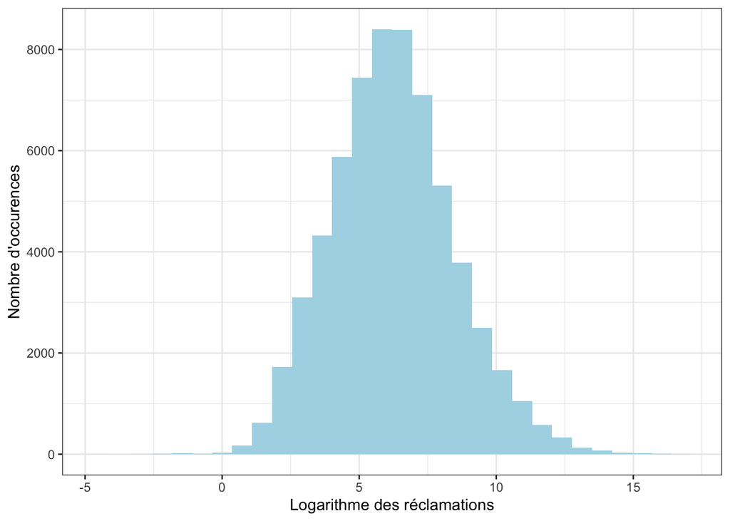

Histogramme du logarithme des montants de réclamation

Comme on peut voir dans la Figure $\ref{fig:HistRecl}$, la distribution est quelque peu asymétrique et la queue est très lourde. En effet, on observe une fréquence somme toute élevée de réclamations très importante. Il n’est pas rare que le logarithme naturel du montant de réclamations atteigne 10 et même plus, alors que la médiane est plutôt autour de 6.

## Exposition

Le minimum est de 1/365, soit d’une journée. Il semble y avoir beaucoup d’annulations de même que des clients particulièrement fidèles puisque la médiane d’exposition est de moins d’un an tandis que la moyenne est de plus de 3 ans.

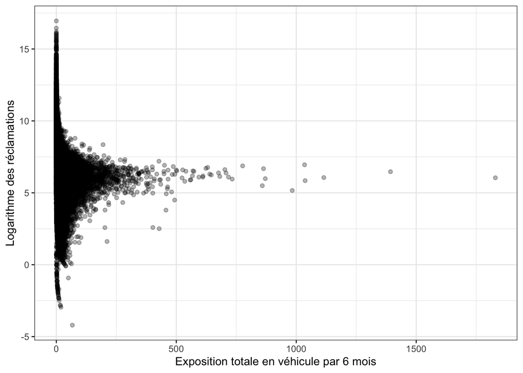

Logarithme des réclamations en fonction de l’exposition

On voit aisément dans la Figure $\ref{fig:PointExpos}$ que la sévérité normalisé tend vers le centre plus la mesure d’exposition est élevée. C’est ce à quoi on peut s’attendre par le théorème centrale limite. La mesure d’exposition semble donc généralement satisfaisante pour l’analyse.

## Genre

La variable **Gender** a quatre niveaux : *Male*, *Female*, *Corporate* et *NA*.

En analysant le lien avec les réclamations, on remarque qu’il n’y a absolument aucune réclamation pour le genre *Corporate*. Étant donné la très grande exposition qui y est associée, c’est évidemment absurde et on en déduit que l’assureur demande l’information sur le conducteur lorsqu’un accident survient et qu’une réclamation est nécessaire. Ainsi, il ajoute l’information rétrospectivement et il sera donc possiblement nécessaire de régrouper le genre *Corporate* avec les clients pour lesquels l’information sur le genre est inconnue.

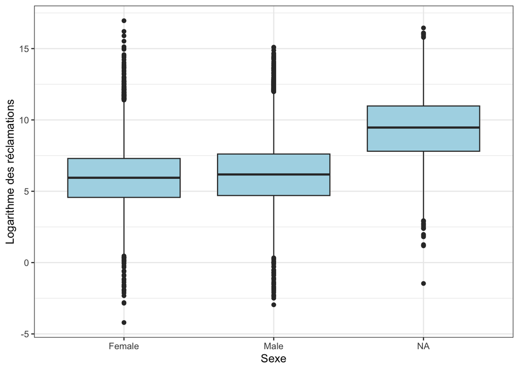

Logarithme des réclamations par genre

En terme de sévérité, les moyennes des réclamations ne semblent pas changer d’un genre à un autre, mais il est possible d’observer à la Figure $\ref{fig:BPGen}$ des réclamations plus élevées en moyenne lorsque le genre est inconnu. Il faut admettre que c’est plutôt surprenant de prime abord. Il convient de noter que c’est l’échantillon le plus faible des trois catégories, mais avec plus de 10 000 réclamations, il est difficile de blâmer le hasard. Une analyse du patron de non-réponse inclaunt les autres variables s’impose.

## Âge du conducteur

À la Figure $\ref{fig:BPDrivAge}$, il est possible d’observer que la tranche d’âge 26-35 ans a, en moyenne, les réclamations les plus élevées. Cela est plutôt intuitif car les jeunes conducteurs sont reconnus pour être plus téméraires et ainsi causer plus d’accidents. Une hypothèse vraisemblable pour expliquer que le groupe de conducteurs de 18 à 25 ans n’a pas des réclamations plus élevées est qu’ils n’ont tout simplement pas les moyens de se procurer des véhicules de grande valeur.

Encore une fois, lorsque l’information est manquante, les réclamations sont bien plus élevées en moyenne.

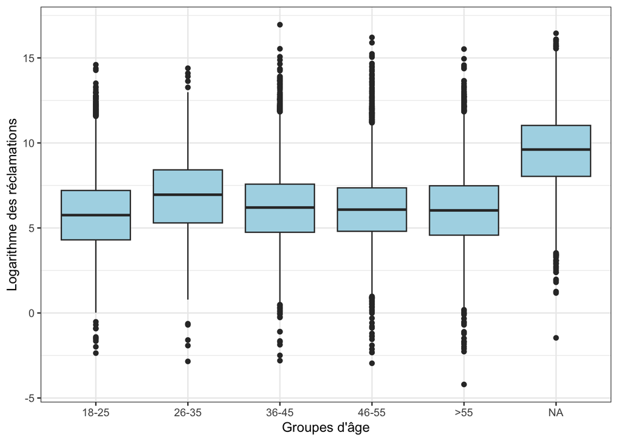

Logarithme des réclamations par Âge de conducteur

## Année du véhicule

Une autre variable explicative disponible est l’année du véhicule.

Selon ce qu’on peut observer à la Figure $\ref{fig:PointVY}$ à l’aide de la régression, l’année du véhicule semble avoir une relation croissante avec le montant des réclamations. Le volume avant les années 90 semble trop faible pour se prononcer sur la tendance de cette époque.

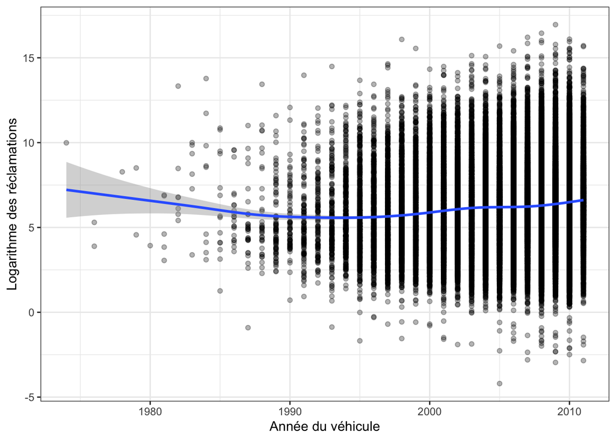

Logarithme des réclamations en fonction de l’année du véhicule

## Modèle du véhicule

Pour l’analyse par marque de véhicule, nous avons décidé de regrouper les marques qui ont moins de 500 observations dans la catégorie *Other*. Nous pouvons donc nous concentrer sur les marques les plus importantes.

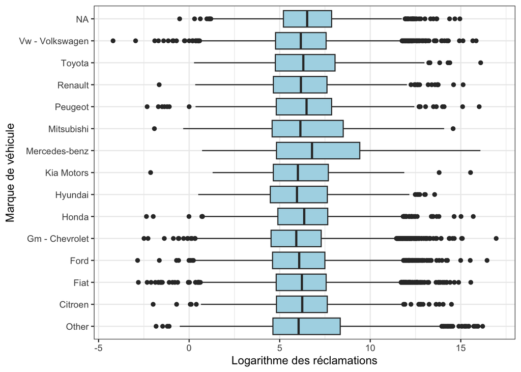

## Région

Pour l’analyse par région, nous avons regrouper les régions qui présentent moins de 2000 observations dans la catégorie *Other*.

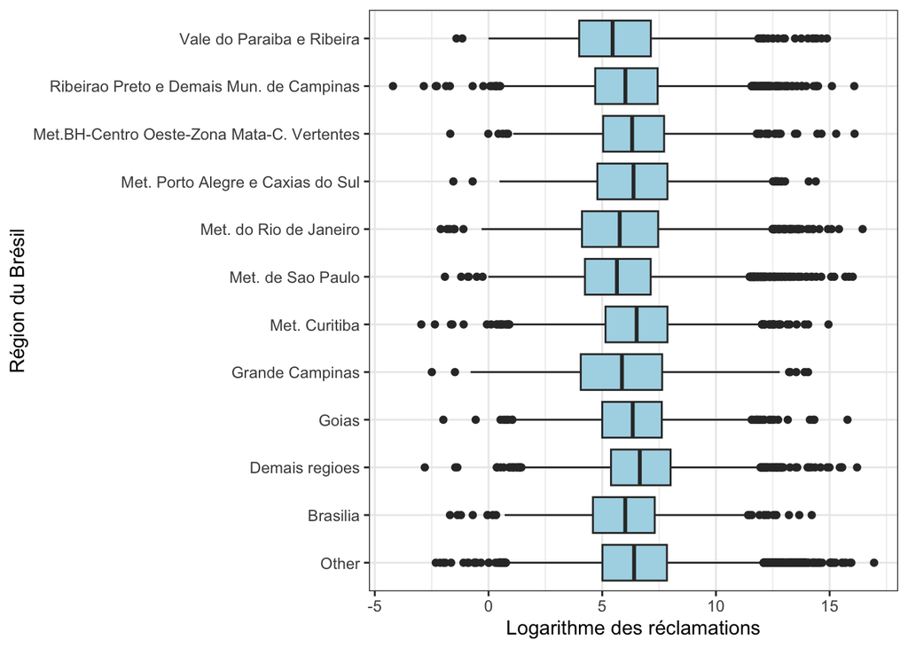

Logarithme des réclamations par région

Similairement, il est possible d’observer à la Figure $\ref{fig:BPArea}$ les réclamations dans les régions les plus récurrentes de la base de données. Sans surprise, les réclamations varient beaucoup même au sein d’une même région et il est difficile d’établir des constats en lesquels l’analyste avisé pourrait réellement avoir confiance.

## État

Pour l’analyse par état, similairement à celle pour la région, nous avons regrouper les états qui présentent moins de 2000 observations dans la catégorie *Other*.

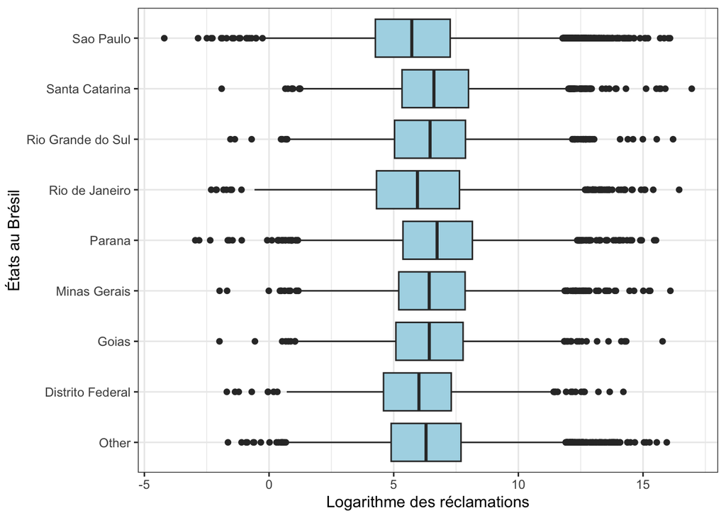

Logarithme des réclamations par état

Un constat similaire est de mise quant au lien entre la ville (ou région administrative selon le cas) et les réclamations, comme le présente la Figure $\ref{fig:BPState}$. S’il est vrai qu’en moyenne les réclamations sont plus faibles dans la ville Rio de Janeiro qui a assurément la réputation d’accueillir une population moins aisée que Santa Catarina par exemple, il n’en demeure pas moins que cela varie énormément et des extrèmes sont observés dans toutes les villes du graphique et il est difficile, de prime abord, de ne pas attribuer les écarts au simple hasard.

## Prime Totale

La prime totale est une variable qui reflète la somme totale de primes pour une combinaison véhicule-assuré donnée. Afin de mieux comprendre la distribution de cette variable, plusieurs analyses peuvent être effectuées:

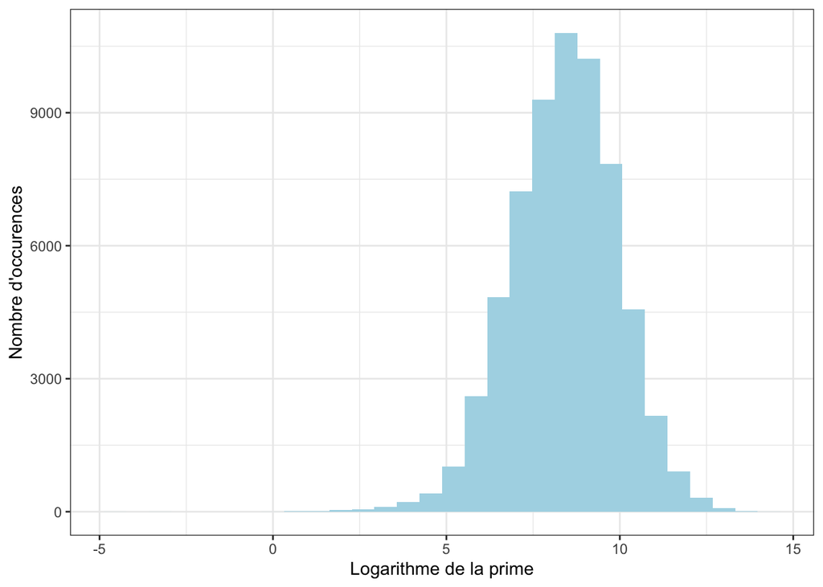

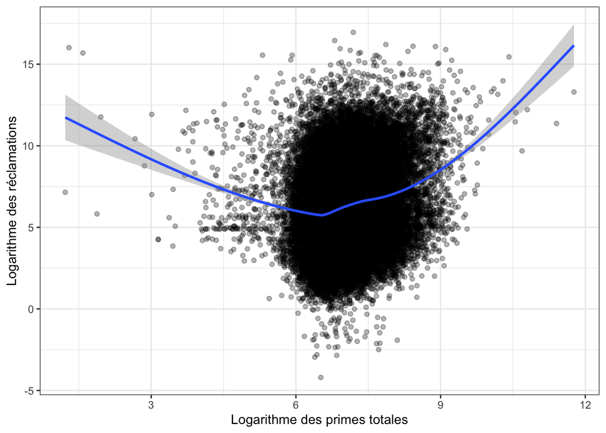

Logarithme des réclamations en fonction de la prime totale

## SumInsAvg

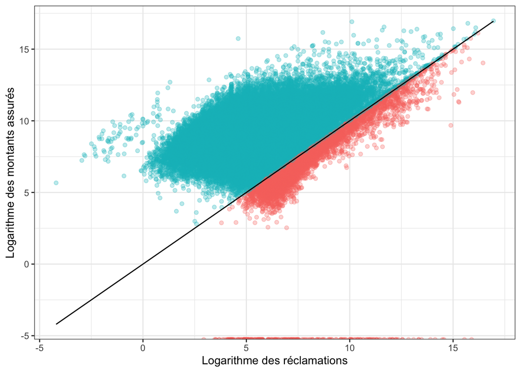

Logarithme des réclamations en fonction de SumInsAvg

On voit donc dans la figure $\ref{fig:PointSumInsAvg}$ que dans la très grande majorité des cas, le montant assuré est supérieure au montant réclamé. On peut croire que les points sous la courbe représente des observations où le montant à assuré a diminué au cours de la période assuré. En effet, Si le montant assuré a été plus élevé à un moment et a diminué subitement, il est possible que la sévérité normalisée dépasse le montant assuré normalisée. Nous croyons donc que notre hypothèse est raisonnable.

La figure $\ref{fig:PointSumInsAvg}$ nous indique aussi qu’il y a une forte corrélation entre le montant assuré et le montant de réclamation. Elle aura donc un grand impact sur le modèle quant à sa conception et nos règles de décisions pour le domaine des prédictions.

# Traitement des valeurs manquantes

## Visualisation

Visualisons les données manquantes.

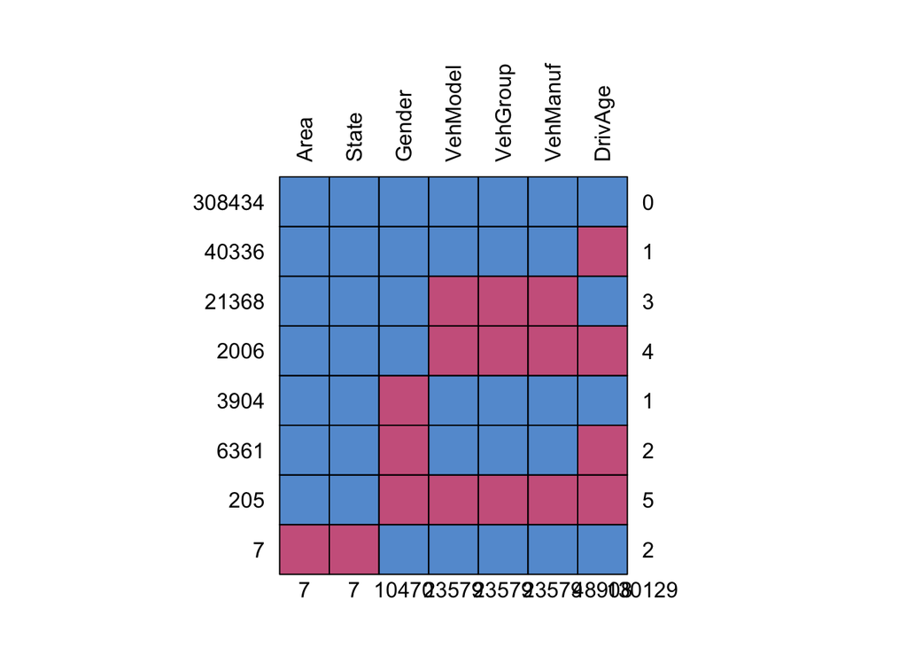

Visualisation des données manquantes

Dans la figure $\ref{fig:MissingDataVis}$, les variables n’ayant pas d’observations manquantes n’ont pas été affichées afin de simplifer le diagramme. Au total, 19.39% des rangées ont au moins une variable manquante.

On remarque que lorsque la variable «Area» est inconnue, la variable «State» l’est aussi. Puisqu’il y a seulement 7 observations manquantes pour ces deux variables, nous les retirons du jeu de données.

Lorsque «VehModel» est manquante, «VehGroup» et «VehManuf» le sont également. Cela est tout à fait attendu, car il n’est pas possible de classifier un véhicule si son modèle n’est pas connu et la variable «VehManuf» est créée à partir de la variable «VehModel». On teste l’hypothèse que le patron de non-réponse de la variable «VehModel» est MCAR. Puisque la variable est catégorielle, le test de khi-carré de Pearson est utilisé. Les tests se retrouvent dans l’annexe. Les *p-values* de ces tests entre le patron de non-réponse de la variable «VehModel» et les variables «Gender», «DrivAge», «State» et «VehYear» se rapprochent de 0. On rejette l’hypothèse nulle. Le patron de non-réponse de la variable «VehModel» n’est pas MCAR. En reproduisant ces tests pour les patrons de non-réponse des variables «VehGroup» et «VehManuf», la conclusion est identique.

La variable «DrivAge» est la plus absente du jeu de données; elle est manquante dans 12.78% des observations. Faisons un diagramme boxplot pour voir s’il y a un lien entre la présence d’une observation manquante pour cette variable et le montant des réclamations.

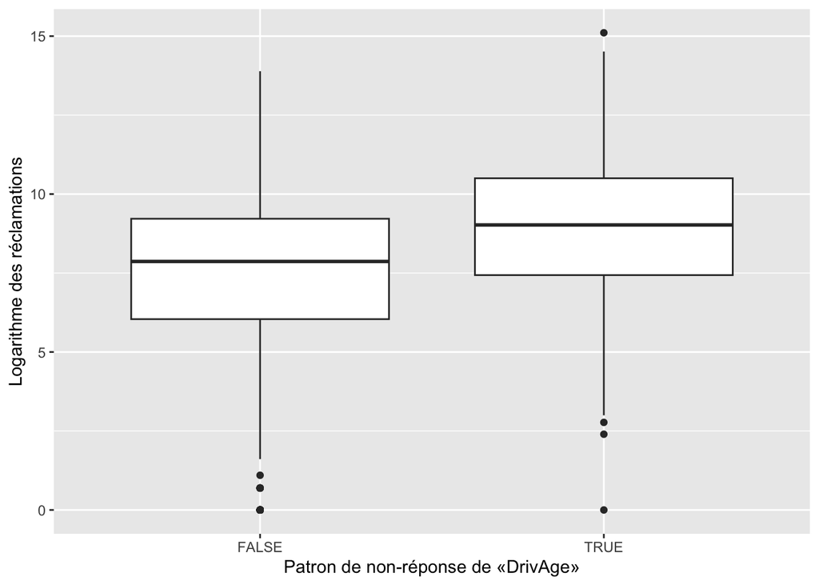

Lien entre le patron de non-réponse de la variable «DrivAge» et le logarithme des réclamations

Vu le grand écart entre le logarithme des réclamations quand la variable «DrivAge» est absente versus quand elle est présente, il semble peu probable que les données manquantes de «DrivAge» soient MCAR. Effectivement, les tests du khi-carré de Pearson rejettent l’hyopthèse nulle que le Patron de non-réponse de cette variable est MCAR. Les *p-values* des tests entre le patron de non-réponse de «DrivAge» et les variables «Gender», «VehManuf», «State» et «Area» sont pratiquement nulles. L’approche des cas complets n’est pas appropriée quand le patron de non-réponse d’est pas MCAR, donc une méthode d’imputation stochastique sera privilégié. Puisqu’il n’y a pas de test pour savoir si les données manquantes sont MAR ou NMAR, il est possible qu’un biais reste présent dans les données après l’imputation.

La variable «Gender» est rarement absente toute seule. Dans la majorité des observations où cette variable est absente, «DrivAge» l’est également. Cela devra être pris en considération s’il est nécessaire d’imputer les données manquantes puisque l’ordre dans lequel les variables sont imputées a une incidence. Testons l’hypothèse nulle que le patron de non-réponse de la variable «Gender» est MCAR avec des tests du khi-carré de Pearson. Ces tests se retrouvent dans l’annexe. Les *p-values* des tests comparant le patron de non-réponse de la variable «Gender» aux variables «DrivAge», «VehManuf», «State» et «Area» sont tous très près de 0. Une fois de plus, l’hypothèse nulle est rejetée : les observations manquantes de la variable «Gender» ne sont pas MCAR.